# 7 Week 7 - Classification 2

## 7.1 Summary:

For local analysis nothing really beats doing your own classification for that particular time point. A statement from this week’s lecture that really stuck with me. This was said when we explored the dynamic world model, which uses a semi-supervised approach to produce a global 10m resolution near real time land cover dataset. It uses surface reflectance data (which is better quality) for labelling but Top of Atmosphere for the model as it includes data from before 2017, which surface reflectance does not. The model also uses a convolutional neural network which uses an algorithm to recognise patterns in data. However, the convolutional model also does not give information about which training data is most useful. While it is useful for broader insights, if working in a local study area it is better to use your own classification or a national product.

#### 7.1.0.1 **This week we covered:**

1. **Object-based analysis** which is based on the idea that pixels are not representative of real life. Therefore groups similar pixels into meaningful vector objects which are then used to classify land cover types. However, OBIA relies on segmentation so small changes in parameters can highly impact the results.
2. Whereas, **sub-pixel analysis** does not consider a pixel to be homogeneous and considers a pixel to be made up of many components so attempts to calculate the proportion of land cover in a pixel itself. To do this we select spectrally pure end members for each land cover type and calculate fractions of each land cover inside the pixel. Which in my opinion is a better method because even 10m pixels are still likely to be heterogeneous.

We also covered accuracy because after producing an output we need to assign an accuracy value to it.

#### 7.1.0.2 **In remote sensing we focus on:**

Producer accuracy - where the classification results meet the expectation of the creator.

User accuracy - how representative the classification is of reality.

Overall accuracy

In today’s lecture we covered various accuracy assessments including Kappa, F1 and the receiver operating characteristic curve. One thing that they all had in common was:

THEY DO NOT ACCOUNT FOR SPATIAL DEPENDENCY!

‘Training’ observations near the ‘test’ observations can provide a kind of ‘sneak preview’: information that should be unavailable to the training dataset (Lovelace et al, 2022). So one thing I do know going forward is to always conduct spatial cross validation on remote sensing (as they are a spatial dataset).

## 7.2 **Application:**

In 2011 Moskal et al., published a study which used OBIA to classify land use and land cover, particularly focusing on urban tree cover in Seattle. The study utilised publicly available hyperspectral imagery from the National Agricultural Imagery Program and QuickBird (used for case study 3). It also used ancillary GIS datasets including parcel shapefiles, roads and buildings footprints. They applied a hierarchical approach using primary segmentation to separate major land cover classes, such as vegetation and impervious surfaces, using spectral, spatial, and contextual information. Within each primary class, they further subdivided the objects using different parameters (e.g., texture, shape, size) to better delineate specific features, like individual tree crowns or smaller patches of vegetation. Rule based classification was then applied to assign land cover class to extracted features.

The image below displays (a) 2002 and (b) 2009 OBIA drive classifications. Where: dark green represents tree cover, light green represents grass and fields and all other colours are impervious surfaces (grey for roads and paved areas, light brown for ground and brown for buildings.

[figure not shown]

(a) 2002 and (b) 2009 OBIA drive classification (Moskal et al., 2011)

To assess the accuracy of each case study, a visual assessment using 2.54 cm resolution, 2002 aerial imagery combined with the 2009 co-registered oblique photography was conducted by an expert image analyst who was not involved in the classification process. The image below represents a confusion matrix similar to the ones we discussed in the lecture to display the accuracy assessment for case study 1.

[figure not shown]

Confusion matrix (Moskal et al., 2011)

The overall accuracy was 71.3% which is reasonably good for broad analysis, however may not be useful for fine scale analysis. Segmentation often over- or under-represented features, while spectral confusion between trees, grass, and shadows reduced accuracy. The 71.3% overall accuracy also meant nearly one in three features were misclassified. Likewise, the assessment was undertaken by a single analyst.

Ghorbanzadeh et al., however aimed to improve the detection of landslides using a combination of deep learning and OBIA. They first generated landslide probability maps with ResU-Net, which identified potential landslide areas based on pixel-level classification. then applied rule-based OBIA using geometrical features including the length-to-width ratio to distinguish between landslides and other similar looking features such as riverbeds. By integrating both approaches, they produced more accurate landslide maps, significantly improving detection performance compared to using each method alone.

## 7.3 **Reflection:**

As much as it has taken a while to wrap my head around classifications, I feel like I am finally starting to get the hang of it. I understand the theory behind OBIA and sub pixel analysis however when putting it into practice during the practical, I felt like my brain was about to explode (It was a lot to take in at once!)

Although I did finally make it to the end of the practical and produced a CART classified map layer. I still would need a lot more time to make sense of the code and more practice in google earth engine.

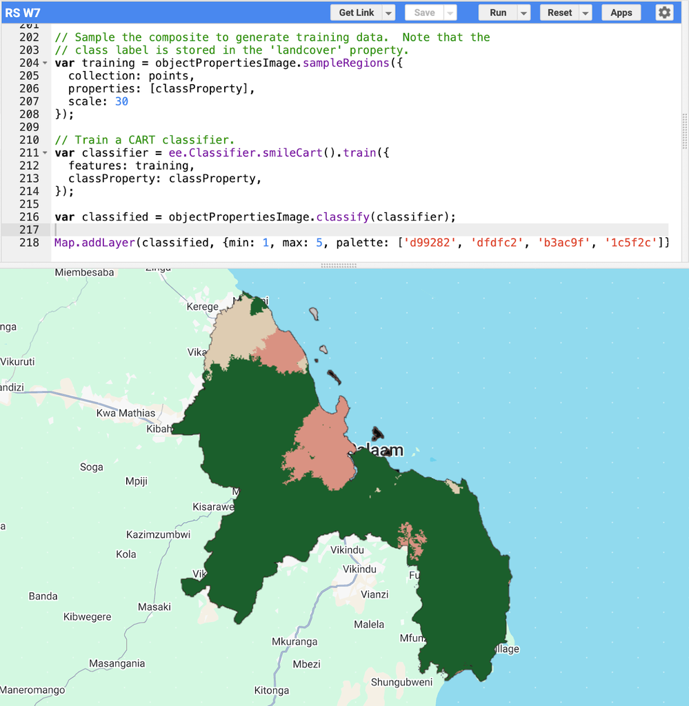

For now, based on what I understand from the material, if I were to choose a classification method I would opt for sub pixel analysis because with 30m landsat data like the one used for this week’s practical many pixels would include mixtures of land cover types. OBIA push each pixel into one class which would not work for heterogeneous blocks.

At work, these methods could be applied to monitoring how green space within urban areas changes over time. The council are often researching leisure and physical activity of residents in the borough and the topic of proximity to greenspace has come up. Likewise, Tower Hamlets is also rapidly growing in population and new developments are often being built to adapt to this. Being able to distinguish between mixed land cover types would make it easier to track whether areas that appear as open space are gradually being lost to development or whether vegetation quality within parks is declining.

## 7.4 References:

Ghorbanzadeh, O., Shahabi, H., Crivellari, A., Homayouni, S., Blaschke, T. and Ghamisi, P. (2022). Landslide detection using deep learning and object-based image analysis. Landslides, 19(4), pp.929–939. doi:https://doi.org/10.1007/s10346-021-01843-x.

Moskal, L.M., Styers, D.M. and Halabisky, M. (2011). Monitoring urban tree cover using object-based image analysis and public domain remotely sensed data. Remote Sensing, 3(10), pp. 2243–2262. doi:10.3390/rs3102243.